# Practical ML Course Project

Yap Ching Loong Ian

March 22, 2017

*An earlier submission was made, dated March 21, 2017. It has been revised to include results from further investigation.*

## 1. Executive Summary

This report documented the attempt to predict the quality of an exercise routine using machine learning (ML). A set of measurement data containing accelerometer readings, time, subject and other identifiers was collected by a [group](http://groupware.les.inf.puc-rio.br/har#weight_lifting_exercises) of researchers. A subset of this data was provided for this exercise and pre-split into two groups, **training** and **testing**. Exercise quality was given by the variable **classe**, a metric split into 5 levels (A-E). This was provided only for the training set. The task was to train a machine learning (ML) algorithm on the training set to predict **classe** in the testing set. No restrictions were placed on the variables that could be used.

An exploratory data analysis was done and it was determined that a single predictor **raw_timestamp_part_1** provided sufficient differentiation with respect to **classe**.

A classification tree model was applied to the training set using only **raw_timestamp_part_1** and the accuracy on the cross-validation (CV) set was found to be above 99%. Predictions for the testing set were checked through the course Quiz and were found to be 100% correct. This approach sufficiently met the requirements of the project task.

Secondary investigation on using just sensor data alone was done. With pure random partitioning of 80% training, 20% CV, a bagged tree ML algorithm managed to achieve >99% on the CV set. However, with partitioning by subject (5 subjects for training, 1 subject for CV), the same algorithm achieved a dismal 24% accuracy.

## 2. Exploratory Data Analysis

Having looked at [reviews](https://www.class-central.com/mooc/1719/coursera-practical-machine-learning) for this course, this author was made aware of the deficiencies of the data in the project. In particular, there were variables available that could easily identify **classe** in the testing set, given that it’s really a “subset” of the training data (i.e. some points removed from time series data from each subject to form the testing set). An exploratory analysis was first done and the following graph was obtained.

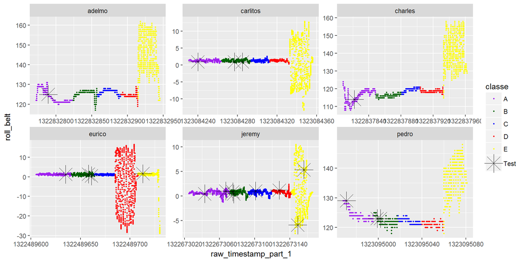

*Plot of roll_belt vs. raw_timestamp_part_1 with all the training and testing data. Coloring is by classe and testing data are marked as another class here. Y-axis variable was arbitrarily chosen. Eurico also appears to have some mislabeled data.*

```r
trainData <- read.csv("pml-training.csv", header = TRUE)
testData <- read.csv("pml-testing.csv", header = TRUE)
testData$classe <- "Test"
testData$problem_id <- NULL

# Combine the data
allData <- rbind(trainData, testData)

# Plot the graph
ggplot(allData, aes(x = raw_timestamp_part_1, y = roll_belt)) +
        geom_point(aes(color = classe, shape = classe, size = classe)) +
        scale_color_manual(values = c("purple", "dark green", "blue", "red", "yellow", "black")) +
        scale_shape_manual(values = c(20, 20, 20, 20, 20, 8)) +
        scale_size_manual(values = c(1, 1, 1, 1, 1, 8)) +
        facet_wrap(~ user_name, scales = "free")
```

One can clearly see that the testing data “fitted” nicely into the test subjects’ time series and hence the variables **user_name** and **raw_timestamp_part_1** appear to provide a straightforward way to determine the testing data **classe** outcome.

In fact, if we were to simply plot all of the subjects measurements on 1 plot:

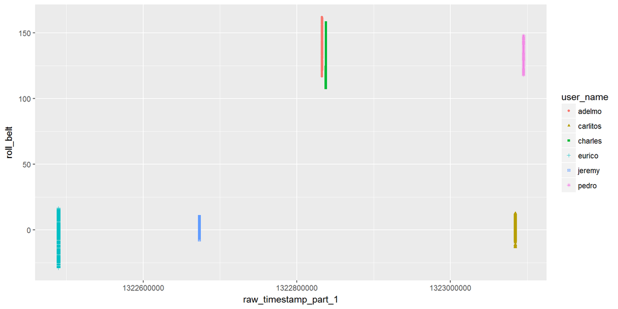

*Plot of roll_belt vs. raw_timestamp_part_1 for all subjects, with coloring by subjects. It’s clear that raw_timestamp_part_1 provides clear differentiation among subjects.*

```r
ggplot(allData, aes(raw_timestamp_part_1, y = roll_belt)) +
    geom_point(aes(color = user_name, shape = user_name), size = 1)
```

It appears that **user_name** will not be necessary since the subjects were tested at times pretty far apart.

## 3. ML with **raw_timestamp_part_1** only

### Modeling + Cross-Validation

The data was 1st partitioned into 80% training, 20% CV.

```r
trainData <- read.csv("pml-training.csv", header = TRUE)

# Select only the relevant columns
trainData <- select(trainData, raw_timestamp_part_1, user_name, roll_belt, classe) # user_name and roll_belt kept for plotting purposes later

# Data partitioning
indTrain <- createDataPartition(y = trainData$classe, p = 0.8, list = FALSE)
trueTrain <- trainData[indTrain, ]
cvTrain <- trainData[-indTrain, ]
```

A classification tree algorithm with default parameters was applied. This algorithm was chosen because of its parsimony.

```r
# Fit a classification tree model
modFit <- train(classe ~ raw_timestamp_part_1, trueTrain, method = 'rpart')
modFit
```

```
## CART
##
## 15699 samples
##     1 predictor
##     5 classes: 'A', 'B', 'C', 'D', 'E'
##
## No pre-processing
## Resampling: Bootstrapped (25 reps)
## Summary of sample sizes: 15699, 15699, 15699, 15699, 15699, 15699, ...
## Resampling results across tuning parameters:
##
##   cp          Accuracy   Kappa
##   0.00000000  0.9924909  0.9905036
##   0.01021362  0.9926154  0.9906613
##   0.02042724  0.7375342  0.6340752
##
## Accuracy was used to select the optimal model using  the largest value.
## The final value used for the model was cp = 0.01021362.
```

Sadly, it appeared that only an accuracy of 99.2% can be achieved.

This model was then used to predict the CV set and a confusion matrix was generated.

```r
# Predict on the CV data
cvPredict <- predict(modFit, cvTrain)

# Generate confusion matrix
confusionMatrix(cvPredict, cvTrain$classe)
```

```
## Confusion Matrix and Statistics
##
##           Reference
## Prediction    A    B    C    D    E
##          A 1114    3    0    0    0
##          B    2  749    0    0    0
##          C    0    7  679    5    0
##          D    0    0    5  636    0
##          E    0    0    0    2  721
##
## Overall Statistics
##
##                Accuracy : 0.9939
##                  95% CI : (0.9909, 0.9961)
##     No Information Rate : 0.2845
##     P-Value [Acc > NIR] : < 2.2e-16
##
##                   Kappa : 0.9923
##  Mcnemar's Test P-Value : NA
##
## Statistics by Class:
##
##                      Class: A Class: B Class: C Class: D Class: E
## Sensitivity            0.9982   0.9868   0.9927   0.9891   1.0000
## Specificity            0.9989   0.9994   0.9963   0.9985   0.9994
## Pos Pred Value         0.9973   0.9973   0.9826   0.9922   0.9972
## Neg Pred Value         0.9993   0.9968   0.9985   0.9979   1.0000
## Prevalence             0.2845   0.1935   0.1744   0.1639   0.1838
## Detection Rate         0.2840   0.1909   0.1731   0.1621   0.1838
## Detection Prevalence   0.2847   0.1914   0.1761   0.1634   0.1843
## Balanced Accuracy      0.9986   0.9931   0.9945   0.9938   0.9997
```

The accuracy on the CV set was 99.4%, comparable to the training set. Exploring the mis-classified data points,

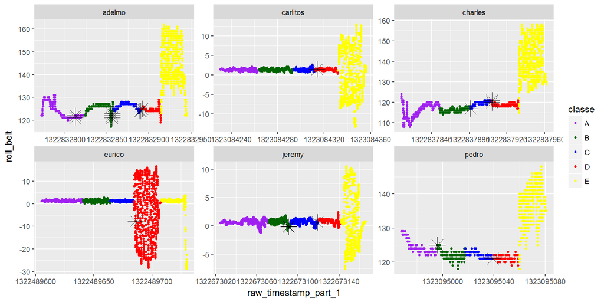

*Plot of roll_belt vs. raw_timestamp_part_1 and coloring by classe, using the whole training set data. Misclassified CV obserations were marked with asterisk.*

```r
ggplot(trainData, aes(x = raw_timestamp_part_1, y = roll_belt)) +
        geom_point(aes(color = classe), size = 1) +
        scale_color_manual(values = c("purple", "dark green", "blue", "red", "yellow")) +
        geom_point(data = cvTrain[cvPredict != cvTrain$classe, ],
                   aes(x = raw_timestamp_part_1, y = roll_belt),
                   shape = 8,
                   size = 6) +
        facet_wrap(~ user_name, scales = "free")
```

It’s clear that the mis-classification occurs at the time boundaries between different **classe**, as might be expected. Given that the testing set times do not appear to have such time boundary issues, as well as the high accuracy of the present model, this author did not pursue the use of other predictors/models.

### Application to Testing Set

The application on the testing set is fairly straightforward. The predictions made through the model led to a 100% grade on the quiz.

```r
testData <- read.csv("pml-testing.csv", header = TRUE)

# Select only the relevant columns
testData <- select(testData, raw_timestamp_part_1, user_name, problem_id) # user_name retained for easy reference

# Prediction
testData$estClasse <- predict(modFit, testData)
testData <- arrange(testData, user_name, raw_timestamp_part_1)
testData
```

```
##    raw_timestamp_part_1 user_name problem_id estClasse
## 1            1322832789    adelmo          4         A
## 2            1323084240  carlitos          9         A
## 3            1323084277  carlitos         11         B
## 4            1323084285  carlitos         18         B
## 5            1322837822   charles         10         A
## 6            1322489635    eurico          5         A
## 7            1322489658    eurico         20         B
## 8            1322489661    eurico         13         B
## 9            1322489713    eurico         16         E
## 10           1322673043    jeremy         14         A
## 11           1322673067    jeremy          2         A
## 12           1322673075    jeremy          3         B
## 13           1322673076    jeremy          8         B
## 14           1322673101    jeremy         12         C
## 15           1322673128    jeremy          7         D
## 16           1322673149    jeremy          6         E
## 17           1322673156    jeremy         15         E
## 18           1323094971     pedro         17         A
## 19           1323094999     pedro         19         B
## 20           1323095002     pedro          1         B
```

## 4. ML without using obvious identifiers

This section will describe the ML modeling without using the obvious identifiers. No prediction was done on the testing set (as provided for the Quiz) but cross-validation results are presented.

### Modeling + Cross-Validation

The data was read in and some cleanup was performed, with largely empty columns and obvious identifiers removed.

```r
trainData <- read.csv("pml-training.csv", header = TRUE)

# Clean data with too many NA or ""
varfracBad <- apply(trainData, 2, function(x) sum(is.na(x) | x == "") / length(x))
varIndToThrow <- which(varfracBad > 0.25)
varIndToThrow <- union(1 : 7, varIndToThrow) # 1-7 contain identifiers
trainData[, varIndToThrow] <- NULL

## Summary of variables
data.frame(var = names(trainData),
           class = sapply(seq_len(ncol(trainData)), function(x) class(trainData[, x])),
           hasNA = apply(trainData, 2, function(x) any(is.na(x))),
           row.names = NULL)
```

```
##                     var   class hasNA
## 1             roll_belt numeric FALSE
## 2            pitch_belt numeric FALSE
## 3              yaw_belt numeric FALSE
## 4      total_accel_belt integer FALSE
## 5          gyros_belt_x numeric FALSE
## 6          gyros_belt_y numeric FALSE
## 7          gyros_belt_z numeric FALSE
## 8          accel_belt_x integer FALSE
## 9          accel_belt_y integer FALSE
## 10         accel_belt_z integer FALSE
## 11        magnet_belt_x integer FALSE
## 12        magnet_belt_y integer FALSE
## 13        magnet_belt_z integer FALSE
## 14             roll_arm numeric FALSE
```

[output cut: 39 more lines]

The original partitioning done earlier was used here in the model. A bagged tree classification model was used.

```r
fitCtrl <- trainControl(method = "cv",               # K-fold CV-10 folds(default)
                        number = 8,                  # No. of sets of K-fold
                        allowParallel = TRUE)
myTreeBagModel <- train(classe ~ .,
                   method = "treebag",
                   nbagg = 20,                        # 20 trees
                   preProcess = c("scale", "center"), # pre-processing with standardization
                   data = trueTrain,
                   trControl = fitCtrl)
```

The results from the K-fold CV were:

```r
myTreeBagModel$resample
```

```
##    Accuracy     Kappa Resample
## 1 0.9928644 0.9909739    Fold1
## 2 0.9969403 0.9961295    Fold2
## 3 0.9938838 0.9922636    Fold3
## 4 0.9959267 0.9948484    Fold4
## 5 0.9959267 0.9948484    Fold5
## 6 0.9928608 0.9909689    Fold6
## 7 0.9954128 0.9941980    Fold7
## 8 0.9933775 0.9916224    Fold8
```

The “internal” CV were pretty good, all above 99%.

The results from the final CV were:

```r
# Check results against CV set
myPreds <- predict(myTreeBagModel, cvTrain)
confusionMatrix(myPreds, cvTrain$classe)
```

```
## Confusion Matrix and Statistics
##
##           Reference
## Prediction    A    B    C    D    E
##          A 1115    1    0    0    0
##          B    1  755    8    0    0
##          C    0    3  672    5    0
##          D    0    0    4  638    0
##          E    0    0    0    0  721
##
## Overall Statistics
##
##                Accuracy : 0.9944
##                  95% CI : (0.9915, 0.9965)
##     No Information Rate : 0.2845
##     P-Value [Acc > NIR] : < 2.2e-16
##
##                   Kappa : 0.9929
##  Mcnemar's Test P-Value : NA
##
## Statistics by Class:
##
##                      Class: A Class: B Class: C Class: D Class: E
## Sensitivity            0.9991   0.9947   0.9825   0.9922   1.0000
## Specificity            0.9996   0.9972   0.9975   0.9988   1.0000
## Pos Pred Value         0.9991   0.9882   0.9882   0.9938   1.0000
## Neg Pred Value         0.9996   0.9987   0.9963   0.9985   1.0000
## Prevalence             0.2845   0.1935   0.1744   0.1639   0.1838
## Detection Rate         0.2842   0.1925   0.1713   0.1626   0.1838
## Detection Prevalence   0.2845   0.1947   0.1733   0.1637   0.1838
## Balanced Accuracy      0.9994   0.9959   0.9900   0.9955   1.0000
```

These true CV results were also great: above 99%.

## 5. ML using 1 test subject as cross-validation

A truer way of determining generalizability would be to remove 1 subject from the training set completely and do cross-validation on him/her. The same cleanup and ML algorithm (bagged tree) was applied here:

```r
trainData <- read.csv("pml-training.csv", header = TRUE)

# Identify 1 user to be test set
indTrain <- which(trainData$user_name != "eurico")

# Clean data with too many NA or ""
varfracBad <- apply(trainData, 2,
                    function(x) sum(is.na(x) | x == "") / length(x))
varIndToThrow <- which(varfracBad > 0.25)
varIndToThrow <- union(1 : 7, varIndToThrow) # 1-7 contain identifiers
trainData[, varIndToThrow] <- NULL

# Partition the data
trueTrain <- trainData[indTrain, ]
cvTrain <- trainData[-indTrain, ]

# Fit bagged tree model
fitCtrl <- trainControl(method = "cv",               # K-fold CV-10 folds(default)
                        number = 8,                  # No. of sets of K-fold
                        allowParallel = TRUE)
myTreeBagModel <- train(classe ~ .,
                   method = "treebag",
                   nbagg = 20,                        # 20 trees
                   preProcess = c("scale", "center"), # pre-processing with standardization
                   data = trueTrain,
                   trControl = fitCtrl)

# Check accuracy from internal CV
myTreeBagModel$resample
```

```
##    Accuracy     Kappa Resample
## 1 0.9956480 0.9944926    Fold1
## 2 0.9898600 0.9871677    Fold2
## 3 0.9864734 0.9828860    Fold3
## 4 0.9830672 0.9785730    Fold4
## 5 0.9874214 0.9840848    Fold5
## 6 0.9855072 0.9816546    Fold6
## 7 0.9903335 0.9877702    Fold7
## 8 0.9874396 0.9841071    Fold8
```

```r
# Check results against CV set
myPreds <- predict(myTreeBagModel, cvTrain)
confusionMatrix(myPreds, cvTrain$classe)
```

```
## Confusion Matrix and Statistics
##
##           Reference
## Prediction   A   B   C   D   E
##          A  76   3   0   0   0
##          B 353 168 135  21  90
##          C   3  20  13  20   0
##          D  30  52  19  39  16
##          E 403 349 322 502 436
##
## Overall Statistics
##
##                Accuracy : 0.2384
##                  95% CI : (0.2235, 0.2539)
##     No Information Rate : 0.2818
##     P-Value [Acc > NIR] : 1
##
##                   Kappa : 0.0671
##  Mcnemar's Test P-Value : <2e-16
##
## Statistics by Class:
##
##                      Class: A Class: B Class: C Class: D Class: E
## Sensitivity           0.08786  0.28378 0.026585  0.06701   0.8044
## Specificity           0.99864  0.75827 0.983340  0.95297   0.3766
## Pos Pred Value        0.96203  0.21904 0.232143  0.25000   0.2167
## Neg Pred Value        0.73621  0.81589 0.842070  0.81366   0.8998
## Prevalence            0.28176  0.19283 0.159283  0.18958   0.1765
## Detection Rate        0.02476  0.05472 0.004235  0.01270   0.1420
## Detection Prevalence  0.02573  0.24984 0.018241  0.05081   0.6554
## Balanced Accuracy     0.54325  0.52103 0.504962  0.50999   0.5905
```

While the internal CV results were fantastic at >98%, the algorithm completely failed with the new subject, **eurico**, achieving an accuracy of only 24%, slightly better than random. This was not particularly surprising, given what was found in the exploratory analysis section.

## Final Remarks

It’s clear that our 1st ML approach using the time variable was fairly silly and non-generalizable despite giving highly accurate results for the testing data.

The 2nd approach using pure sensor readings also had very good cross-validation results.

However, the same classification algorithm trained on 5 subjects and cross-validated on a 6th gave rubbish results, achieving just slightly better accuracy than chance. It’s clear that the either more training data is required or the general approach of using the data as-is is unsuitable. More reliable classification of quality may require the analysis of a whole time series rather than single points in time. This author noted that the original authors of the study used methods such as windowing and measured parameters such as kurtosis and skew of several measurements for each window. This line of approach is however beyond the scope of this project.